# Bioinformatics class 14 differential gene expression

Amanda Alker

5/18/2018

Make sure we can download DESeq2

```r
#see the detailed installation handout on the website
library(BiocInstaller)
#biocLite("DESeq2")
```

Read the data into R

```r
#stringsAsFactors makes catagorical factors but this program doesnt like them (ie treat as normal vector)
metadata <-read.csv("data/airway_metadata.csv", stringsAsFactors = FALSE)
counts <- read.csv("data/airway_scaledcounts.csv", stringsAsFactors = FALSE)
```

Let’s look at them

```r
head(counts)
```

```
##           ensgene SRR1039508 SRR1039509 SRR1039512 SRR1039513 SRR1039516
## 1 ENSG00000000003        723        486        904        445       1170
## 2 ENSG00000000005          0          0          0          0          0
## 3 ENSG00000000419        467        523        616        371        582
## 4 ENSG00000000457        347        258        364        237        318
## 5 ENSG00000000460         96         81         73         66        118
## 6 ENSG00000000938          0          0          1          0          2
##   SRR1039517 SRR1039520 SRR1039521
## 1       1097        806        604
## 2          0          0          0
## 3        781        417        509
## 4        447        330        324
## 5         94        102         74
## 6          0          0          0
```

```r
#GEO collection is like the ENTREZ or SRA of NCBI
#check to make sure the IDs are distributed properly amongst row and columns
head(metadata)
```

```
##           id     dex celltype     geo_id
## 1 SRR1039508 control   N61311 GSM1275862
## 2 SRR1039509 treated   N61311 GSM1275863
## 3 SRR1039512 control  N052611 GSM1275866
## 4 SRR1039513 treated  N052611 GSM1275867
## 5 SRR1039516 control  N080611 GSM1275870
## 6 SRR1039517 treated  N080611 GSM1275871
```

```r
colnames(counts)[-1] == metadata$id
```

```
## [1] TRUE TRUE TRUE TRUE TRUE TRUE TRUE TRUE
```

## Let’s start to mess with differential gene expression (this isnt the real workflow)

```r
View(metadata)
```

```r
control <- metadata[metadata [, "dex"] =="control", ]
control
```

```
##           id     dex celltype     geo_id
## 1 SRR1039508 control   N61311 GSM1275862
## 3 SRR1039512 control  N052611 GSM1275866
## 5 SRR1039516 control  N080611 GSM1275870
## 7 SRR1039520 control  N061011 GSM1275874
```

```r
#check the logic to make sure that the metadata corresponds to the rows
#metadata[ with the inside function] will give the controls only

control.mean <- rowSums( counts[ ,control$id] )/4
#control$id will give us just the counts for the control ids

names(control.mean) <- counts$ensgene
#put the ids back on to make sure we dont get confused
```

How do we make this more robust?

```r
#get rid of the 4, because it is hardcoded
#nrow(control) should be substituted for 4
control.mean <- rowSums( counts[ ,control$id] )/nrow(control)
head(control.mean)
```

```
## [1] 900.75   0.00 520.50 339.75  97.25   0.75
```

Now lets do it again with the treated…

```r
treated <- metadata[metadata [, "dex"] =="treated", ]
control
```

```
##           id     dex celltype     geo_id
## 1 SRR1039508 control   N61311 GSM1275862
## 3 SRR1039512 control  N052611 GSM1275866
## 5 SRR1039516 control  N080611 GSM1275870
## 7 SRR1039520 control  N061011 GSM1275874
```

```r
treated.mean <- rowSums( counts[ ,treated$id] )/nrow(treated)

names(treated.mean) <- counts$ensgene
head(treated.mean)
```

```
## ENSG00000000003 ENSG00000000005 ENSG00000000419 ENSG00000000457
##          658.00            0.00          546.00          316.50
## ENSG00000000460 ENSG00000000938
##           78.75            0.00
```

```r
meancounts <- data.frame(control.mean, treated.mean)
head(meancounts)
```

```
##                 control.mean treated.mean
## ENSG00000000003       900.75       658.00
## ENSG00000000005         0.00         0.00
## ENSG00000000419       520.50       546.00
## ENSG00000000457       339.75       316.50
## ENSG00000000460        97.25        78.75
## ENSG00000000938         0.75         0.00
```

```r
colSums(meancounts)
```

```
## control.mean treated.mean
##     23005324     22196524
```

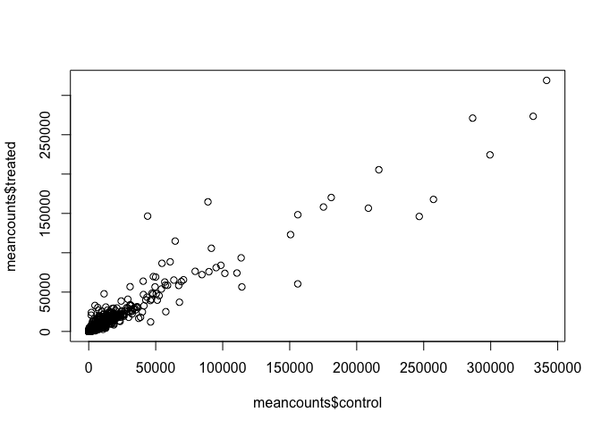

```r
plot(meancounts$control, meancounts$treated)
```

```r
#notice all of the points are on top of each other. Normally, we fix this by plotting on a log scale
```

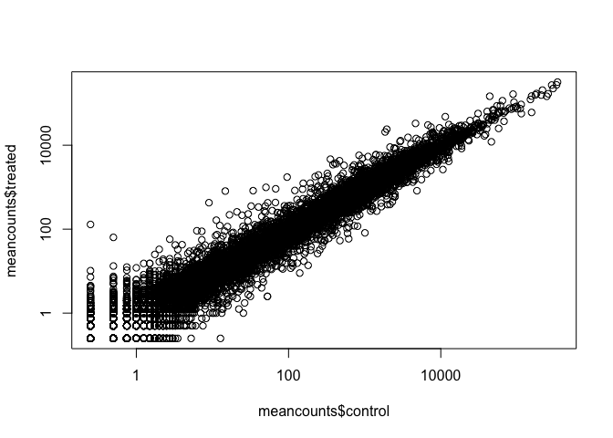

```r
plot(meancounts$control, meancounts$treated, log = "xy")
```

```r
#make the log2foldchange in a new column
meancounts$log2fc <- log2(meancounts[,"treated.mean"]/meancounts[,"control.mean"])
head(meancounts)
```

```
##                 control.mean treated.mean      log2fc
## ENSG00000000003       900.75       658.00 -0.45303916
## ENSG00000000005         0.00         0.00         NaN
## ENSG00000000419       520.50       546.00  0.06900279
## ENSG00000000457       339.75       316.50 -0.10226805
## ENSG00000000460        97.25        78.75 -0.30441833
## ENSG00000000938         0.75         0.00        -Inf
```

We need to filter out the zeros because they are messing with the log plotting of our data

practice making a matrix to play with

```r
x <- matrix(1:10, ncol = 2, byrow = TRUE)

x[5,2] <- 0
x
```

```
##      [,1] [,2]
## [1,]    1    2
## [2,]    3    4
## [3,]    5    6
## [4,]    7    8
## [5,]    9    0
```

```r
x == 0
```

```
##       [,1]  [,2]
## [1,] FALSE FALSE
## [2,] FALSE FALSE
## [3,] FALSE FALSE
## [4,] FALSE FALSE
## [5,] FALSE  TRUE
```

```r
which(x==0)
```

```
## [1] 10
```

```r
#want it to return row and column
which(x ==0, arr.ind = TRUE)
```

```
##      row col
## [1,]   5   2
```

```r
zero.vals <- which(meancounts[,1:2]== 0, arr.ind = TRUE)
head(zero.vals)
```

```
##                 row col
## ENSG00000000005   2   1
## ENSG00000004848  65   1
## ENSG00000004948  70   1
## ENSG00000005001  73   1
## ENSG00000006059 121   1
## ENSG00000006071 123   1
```

Now we need to remove the zero count containing genes

```r
to.rm <- unique(zero.vals[,1])
mycounts <- meancounts[-to.rm,]
head(mycounts)
```

```
##                 control.mean treated.mean      log2fc
## ENSG00000000003       900.75       658.00 -0.45303916
## ENSG00000000419       520.50       546.00  0.06900279
## ENSG00000000457       339.75       316.50 -0.10226805
## ENSG00000000460        97.25        78.75 -0.30441833
## ENSG00000000971      5219.00      6687.50  0.35769358
## ENSG00000001036      2327.00      1785.75 -0.38194109
```

Differentially expressed rule of thumb is logfold change of 2

```r
up.ind <- mycounts$log2fc > 2
down.ind <- mycounts$log2fc < -2
head(up.ind)
```

```
## [1] FALSE FALSE FALSE FALSE FALSE FALSE
```

```r
#this gives logical responses
#use sum to give how many are differentially expressed
```

```r
paste("Up:", sum(up.ind))
```

```
## [1] "Up: 250"
```

```r
paste("Down:", sum(down.ind))
```

```
## [1] "Down: 367"
```

```r
#use the paste function to have the names of your choice printed out
```